**Universidad de Los Andes - Facultad de Economía**  
**Machine Learning para Business Intelligence**  
*Paula Rodríguez, Juan S. Moreno, Mateo Dulce*

# Clase 3: Modelos de Regresión

En esta clase se cubriran los modelos estándar de regresión:

- Mínimos cuadrados ordinarios (Regresión Lineal)
- Regresión polinomial
- Regresión Logística
- Linear Discriminant Analysis
- Regularización L1 y L2
- Árboles de regresión

Además, para evaluar el desempeño de los modelos implementados, se estudiarán las métricas de evaluación:

- R-cuadrado
- MSE
- MAPE

[figure not shown]

*(Imagen tomada de [Medium - Different types of Machine learning and their types.](https://medium.com/deep-math-machine-learning-ai/different-types-of-machine-learning-and-their-types-34760b9128a2))*

## 0. Introducción a Scikit-Learn

Existen varias librerias de Python que proveen implementaciones solidas de multiples algoritmos de aprendizaje de máquinas. Una de las más conocidas es [Scikit-Learn](http://scikit-learn.org). Scikit-Learn se caracteriza por ser una API limpia, uniforme y optimizada, y por tener una documentación en línea muy útil y completa.Una ventaja de esta uniformidad es que una vez que comprende el uso básico y la sintaxis de Scikit-Learn para un tipo de modelo, cambiar a un nuevo modelo o algoritmo es muy sencillo.

### Uso básico de la API

Por lo general, los pasos a seguir para utilizar los modelos implementados en Scikit-Learn son:

1. Seleccionar una clase de modelo importando la clase de estimador apropiada de Scikit-Learn.
2. Seleccionar los hiper parámetros del modelo al instanciar la clase anterior con estos valores.
3. Organizar los datos en una matriz de variables y un vector objetivo.
4. Ajustar el modelo a los datos llamando al método `fit ()` de la instancia del modelo.
5. Evaluar el modelo en nuevos datos.

## 1. Mínimos Cuadrados Ordinarios

### Regresión lineal univariada

Los modelos de regresión lineal son un buen punto de partida para las tareas de regresión. Dichos modelos son populares porque pueden ajustarse muy rápidamente y son muy interpretables.

Comenzaremos con la regresión lineal más familiar, un ajuste en línea recta a los datos. Un ajuste en línea recta es un modelo de la forma $$ y = ax + b $$ donde $a$ es la *pendiente*, y $b$ is el *intercepto*.

Considere los siguientes datos, que están dispersos alrededor de un modelo lineal con una pendiente de 2 y una intersección de -5:

```python
# importar paquetes estandar
%matplotlib inline
import matplotlib.pyplot as plt
import seaborn as sns; sns.set()
import numpy as np
```

### Generar datos sintéticos

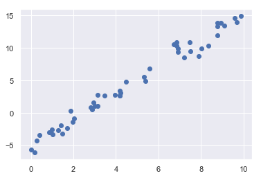

```python
# para tener replicabilidad
rng = np.random.RandomState(1)

# generamos puntos distribuidos de manera uniforme entre 0 y 10
x = 10 * rng.rand(50,1)

# generamos los valores de y usando un modelo lineal con pendiente 2
# e intercepto -5 mas un ruido alatorio
y = 2 * x[:,0] - 5 + rng.randn(50)

# construit un grafico de puntos
plt.scatter(x, y);
```

### Encontrar el mejor ajuste (usando Numpy)

Escribiendo el modelo de forma matricial tenemos: $Y = X^T \beta$.

Queremos encontrar $\hat \beta$ que minimice el costo $(Y-\hat Y)^2$ donde $\hat Y = X^T \hat \beta$.  
Esto es $\hat \beta = (X^TX)^{-1}X^TY$

```python
# resolvamos el problema utilziando el paquete numpy
import numpy as np

print(type(x),type(y))
```

```
<class 'numpy.ndarray'> <class 'numpy.ndarray'>
```

```python
# creamos la matriz que contiene una columna de 1's y la variable x
X = np.matrix([np.ones(len(x),dtype=x.dtype),x.reshape(-1)])

# np.matrix toma cada entrada como una fila.
# trasponemos para tener observaciones x variables
X=X.T
```

```python
# estimación de beta
beta_estimado = (np.linalg.inv(X.T*X)*X.T).dot(y)
print("Pendiente del modelo: {}".format(beta_estimado[0,1]))
print("Intercepto del modelo: {}".format(beta_estimado[0,0]))
```

```
Pendiente del modelo: 2.0272088103606967
Intercepto del modelo: -4.9985770855532135
```

### Encontrar el mejor ajuste utilizando Scikit-Learn

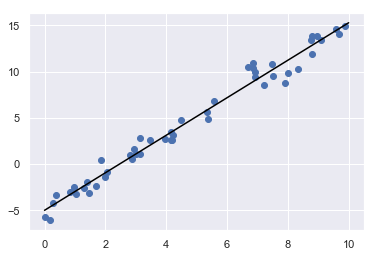

```python
#importar LinearRegression de Scikit-Learn
from sklearn.linear_model import LinearRegression

# crear un modelo lineal con intercepto
model = LinearRegression(fit_intercept=True)

# ajustar el modelo a los datos
model.fit(x, y)

# graficar la funcion lineal estimada
xfit = np.linspace(0, 10, 1000)
yfit = model.predict(xfit[:, np.newaxis])

# build plot
plt.scatter(x, y)
plt.plot(xfit, yfit, color='black');
```

```python
print("Pendiente del modelo:    ", model.coef_[0])
print("Intercepto del modelo:", model.intercept_)
```

```
Pendiente del modelo:     2.027208810360695
Intercepto del modelo: -4.998577085553202
```